# Theoretical Lot Audits Data Observations

2025-06-25

Loading Data

```r
theoretical_lot_audits = read.csv(file = "data/assesment.csv")
```

### **DATA CLEANING**

There are rows where there is a System.Entry.Date and a System.User but nothing in the Adjusted..Pcs column.

```r
head(theoretical_lot_audits[which(theoretical_lot_audits$Adjusted..Pcs == ""), ])
```

```
##    System.Entry.Date System.User    Lot. Received.Date Style.        Desc.
## 17         5/31/2022         Don  Lot949     5/15/2021 Style2 Description2
## 23                                Lot742     7/30/2020 Style4 Description4
## 36                                Lot689     5/18/2021 Style9 Description9
## 37                                Lot690     3/23/2022 Style9 Description9
## 40                                Lot694     5/21/2022 Style9 Description9
## 42                               Lot2285      1/8/2022 Style9 Description9
##      Color. Received.Pcs Initial.Stock.Pcs Adjusted..Pcs Final.Count.Pcs
## 17 Color140            2                 2                             2
## 23  Color20            2                 2                             2
## 36  Color61            1                 1                             1
## 37  Color20            4                 4                             4
## 40  Color20            5                 5                             5
## 42 Color188            1                 1                             1
```

```r
null_adjusted_audits = theoretical_lot_audits[which(theoretical_lot_audits$Adjusted..Pcs == "" & theoretical_lot_audits$System.User != ""), ]

null_adjusted_audits[1:20, ]# first 20 rows
```

```
##      System.Entry.Date System.User    Lot. Received.Date   Style.
## 17           5/31/2022         Don  Lot949     5/15/2021   Style2
## 160          5/27/2022         Dan Lot2228     1/29/2022  Style16
## 249          5/30/2022         Dan Lot1045    11/24/2021  Style20
## 383          5/27/2022         Dan Lot1189     3/22/2022  Style28
## 469          5/26/2022         Don Lot1291     4/26/2022  Style36
## 482          5/31/2022         Dan Lot1499      5/2/2022  Style36
## 487          5/27/2022         Dan Lot2429     3/31/2022  Style36
## 517          5/27/2022        Jill Lot1910     3/25/2022  Style48
## 586          5/25/2022        John Lot2406         44678  Style55
## 994          5/27/2022        Jill Lot1795    10/12/2021 Style114
## 1063         5/27/2022        Jill Lot1949     4/15/2022 Style119
## 1117         5/27/2022         Dan Lot1441     3/29/2022 Style123
## 1229         5/27/2022        John Lot1714     6/16/2021 Style132
## 1312         5/25/2022         Don Lot2286     1/25/2022 Style142
```

[output cut: 48 more lines]

```r
null_adjusted_audits$Initial.Stock.Pcs - null_adjusted_audits$Final.Count.Pcs
```

```
##  [1]  0  0  0  0  0  0  0  0  0  0  0  0  0  0  0  0  0  0 NA
```

I’ll replace the null values with 0

```r
adjusted_pc_null_index = which(theoretical_lot_audits$Adjusted..Pcs == "" & theoretical_lot_audits$System.User != "")

theoretical_lot_audits$Adjusted..Pcs[theoretical_lot_audits$Adjusted..Pcs == "" & theoretical_lot_audits$System.User != ""] = rep(0, 19)
```

This is the new data frame with 0 instead of null values

```r
theoretical_lot_audits[1:20, ] # first 20 rows
```

```
##    System.Entry.Date System.User    Lot. Received.Date Style.        Desc.
## 1          5/26/2022         Don   Lot77     3/22/2022 Style1 Description1
## 2          5/31/2022         Sam  Lot665     5/25/2022 Style1 Description1
## 3          5/23/2022         Sam Lot1171     7/23/2020 Style1 Description1
## 4          5/31/2022         Sam Lot1278      2/5/2021 Style1 Description1
## 5          5/31/2022         Sam Lot1279      2/5/2021 Style1 Description1
## 6          5/31/2022         Dan Lot1301     12/6/2021 Style1 Description1
## 7          5/26/2022         Sam Lot1302     12/3/2021 Style1 Description1
## 8          5/31/2022         Dan Lot1312     5/13/2021 Style1 Description1
## 9          5/31/2022        John Lot1313     11/5/2021 Style1 Description1
## 10         5/31/2022        John Lot1314     11/5/2021 Style1 Description1
## 11         5/31/2022        John Lot1315     11/6/2021 Style1 Description1
## 12         5/31/2022         Don Lot1324     12/3/2021 Style1 Description1
## 13          6/2/2022         Dan Lot1325     2/17/2022 Style1 Description1
## 14         5/25/2022         Don Lot1327         44573 Style1 Description1
```

[output cut: 27 more lines]

This shows that there is still an issue with the Adjusted.Pcs column as there is a “|” where there should be a number

```r
#
unique(theoretical_lot_audits$Adjusted..Pcs[which(theoretical_lot_audits$Adjusted..Pcs != "")])
```

```
##  [1] "0"    "-2"   "-4"   "-1"   "-1.5" "1"    "4"    "2"    "-3"   "1.5"
## [11] "-4.3" "0.5"  "3"    "-1.3" "|"    "-0.2" "-0.5" "3.5"  "-2.5" "2.5"
```

```r
theoretical_lot_audits[which(theoretical_lot_audits$Adjusted..Pcs == "|"), ]
```

```
##      System.Entry.Date System.User    Lot. Received.Date   Style.
## 1410         5/30/2022         Dan Lot2485     3/22/2022 Style150
##               Desc.   Color. Received.Pcs Initial.Stock.Pcs Adjusted..Pcs
## 1410 Description150 Color139            2                 2             |
##      Final.Count.Pcs
## 1410               2
```

Since it should be 0 like the null values lets fix it.

```r
# fixed the data entry error
theoretical_lot_audits$Adjusted..Pcs[theoretical_lot_audits$Adjusted..Pcs == "|" & theoretical_lot_audits$System.User != ""] = c(0)

theoretical_lot_audits[which(theoretical_lot_audits$Lot. == "Lot2485"), ]
```

```
##      System.Entry.Date System.User    Lot. Received.Date   Style.
## 1410         5/30/2022         Dan Lot2485     3/22/2022 Style150
##               Desc.   Color. Received.Pcs Initial.Stock.Pcs Adjusted..Pcs
## 1410 Description150 Color139            2                 2             0
##      Final.Count.Pcs
## 1410               2
```

Another Error: Fix data entry error for incorrect system entry date

```r
theoretical_lot_audits[which(theoretical_lot_audits$System.Entry.Date == "5/31/0202"), ]
```

```
##      System.Entry.Date System.User   Lot. Received.Date   Style.          Desc.
## 2021         5/31/0202        John Lot206      7/1/2021 Style197 Description197
##        Color. Received.Pcs Initial.Stock.Pcs Adjusted..Pcs Final.Count.Pcs
## 2021 Color140            2                 2             0               2
```

```r
theoretical_lot_audits$System.Entry.Date[theoretical_lot_audits$System.Entry.Date == "5/31/0202"] = "5/31/2022"

theoretical_lot_audits[2021, ]
```

```
##      System.Entry.Date System.User   Lot. Received.Date   Style.          Desc.
## 2021         5/31/2022        John Lot206      7/1/2021 Style197 Description197
##        Color. Received.Pcs Initial.Stock.Pcs Adjusted..Pcs Final.Count.Pcs
## 2021 Color140            2                 2             0               2
```

Would clean but not enough information to.

```r
# used excel pivot tables to find errors

# there appears to have been an audit where the admin did not enter their name or the system entry date
theoretical_lot_audits[which(theoretical_lot_audits$System.User == "" & theoretical_lot_audits$Adjusted..Pcs != ""), ]
```

```
##      System.Entry.Date System.User    Lot. Received.Date   Style.
## 1427                               Lot2519     5/27/2022 Style150
##               Desc.  Color. Received.Pcs Initial.Stock.Pcs Adjusted..Pcs
## 1427 Description150 Color20            2                 2             0
##      Final.Count.Pcs
## 1427               2
```

### **DATA OBSERVATIONS**

#### **Total Number of Unique Lots**

Look for duplicate lots.

```r
duplicates = theoretical_lot_audits$Lot.[duplicated(theoretical_lot_audits$Lot.)]

duplicates[1:20] # rest are also null
```

```
##  [1] "Lot330"  "Lot34"   "Lot36"   "Lot78"   "Lot81"   "Lot1782" ""
##  [8] ""        ""        ""        ""        ""        ""        ""
## [15] ""        ""        ""        ""        ""        ""
```

There are 6 repeat lots

```r
duplicated_lots = duplicates[which(duplicates != "")]
duplicated_lots
```

```
## [1] "Lot330"  "Lot34"   "Lot36"   "Lot78"   "Lot81"   "Lot1782"
```

**THERE ARE 2562 UNIQUE LOTS**

```r
# number of total lots - number of duplicate lots
num_unique_lots = length(theoretical_lot_audits$Lot.[which(theoretical_lot_audits$Lot. != "")]) - length(duplicated_lots)

# number of unique lots
paste("THERE ARE",num_unique_lots, "UNIQUE LOTS")
```

```
## [1] "THERE ARE 2562 UNIQUE LOTS"
```

#### **Unique Lots Audited (# & %)**

Every audited lot.

```r
audited_lots_df = theoretical_lot_audits[which(theoretical_lot_audits$Adjusted..Pcs != ""), ]

audited_lots_df[1:20, ] # first 20 rows
```

```
##    System.Entry.Date System.User    Lot. Received.Date Style.        Desc.
## 1          5/26/2022         Don   Lot77     3/22/2022 Style1 Description1
## 2          5/31/2022         Sam  Lot665     5/25/2022 Style1 Description1
## 3          5/23/2022         Sam Lot1171     7/23/2020 Style1 Description1
## 4          5/31/2022         Sam Lot1278      2/5/2021 Style1 Description1
## 5          5/31/2022         Sam Lot1279      2/5/2021 Style1 Description1
## 6          5/31/2022         Dan Lot1301     12/6/2021 Style1 Description1
## 7          5/26/2022         Sam Lot1302     12/3/2021 Style1 Description1
## 8          5/31/2022         Dan Lot1312     5/13/2021 Style1 Description1
## 9          5/31/2022        John Lot1313     11/5/2021 Style1 Description1
## 10         5/31/2022        John Lot1314     11/5/2021 Style1 Description1
## 11         5/31/2022        John Lot1315     11/6/2021 Style1 Description1
## 12         5/31/2022         Don Lot1324     12/3/2021 Style1 Description1
## 13          6/2/2022         Dan Lot1325     2/17/2022 Style1 Description1
## 14         5/25/2022         Don Lot1327         44573 Style1 Description1
```

[output cut: 27 more lines]

Find duplicate audited lots.

```r
# duplicate audited lots
audited_duplicates = audited_lots_df$Lot.[duplicated(audited_lots_df$Lot.)]

audited_duplicates
```

```
## [1] "Lot330"  "Lot34"   "Lot36"   "Lot78"   "Lot81"   "Lot1782"
```

**THERE ARE 2463 UNIQUE AUDITED LOTS**

```r
num_unique_audited_lots = dim(audited_lots_df)[1] - length(audited_duplicates)
paste("THERE ARE",num_unique_audited_lots, "UNIQUE AUDITED LOTS")
```

```
## [1] "THERE ARE 2463 UNIQUE AUDITED LOTS"
```

**96.14 PERCENT OF UNIQUE LOTS HAVE BEEN AUDITED**

```r
# percentage of unique lots audited
percent_audited_unique_lots = (num_unique_audited_lots / num_unique_lots) * 100
paste(round(percent_audited_unique_lots, 2), "PERCENT OF UNIQUE LOTS HAVE BEEN AUDITED")
```

```
## [1] "96.14 PERCENT OF UNIQUE LOTS HAVE BEEN AUDITED"
```

#### **Unique Lots Remaining to be Audited (# & %)**

Every lot that isn’t audited.

```r
not_audited_lots_df = theoretical_lot_audits[which(theoretical_lot_audits$Adjusted..Pcs == "" & theoretical_lot_audits$Lot. != "" ), ]

head(not_audited_lots_df) #shows first 6 rows
```

```
##    System.Entry.Date System.User    Lot. Received.Date  Style.         Desc.
## 23                                Lot742     7/30/2020  Style4  Description4
## 36                                Lot689     5/18/2021  Style9  Description9
## 37                                Lot690     3/23/2022  Style9  Description9
## 40                                Lot694     5/21/2022  Style9  Description9
## 42                               Lot2285      1/8/2022  Style9  Description9
## 53                                Lot611     1/31/2022 Style10 Description10
##      Color. Received.Pcs Initial.Stock.Pcs Adjusted..Pcs Final.Count.Pcs
## 23  Color20            2                 2                             2
## 36  Color61            1                 1                             1
## 37  Color20            4                 4                             4
## 40  Color20            5                 5                             5
## 42 Color188            1                 1                             1
## 53  Color31            1                 1                             1
```

Shows if there are any duplicate not audited lots.

```r
not_audited_duplicates = not_audited_lots_df$Lot.[duplicated(not_audited_lots_df$Lot.)]

not_audited_duplicates
```

```
## character(0)
```

**99 LOTS HAVEN’T BEEN AUDITED**

```r
# since there are no duplicates we can use just the dimensions of the data frame

# number of unique lots that aren't audited
paste(dim(not_audited_lots_df)[1], "LOTS HAVEN'T BEEN AUDITED" )
```

```
## [1] "99 LOTS HAVEN'T BEEN AUDITED"
```

**3.86 PERCENT OF LOTS HAVENT BEEN AUDITED**

```r
# percentage of unique lots not yet audited

paste(round((dim(not_audited_lots_df)[1]  / num_unique_lots) * 100, 2), "PERCENT OF LOTS HAVENT BEEN AUDITED")
```

```
## [1] "3.86 PERCENT OF LOTS HAVENT BEEN AUDITED"
```

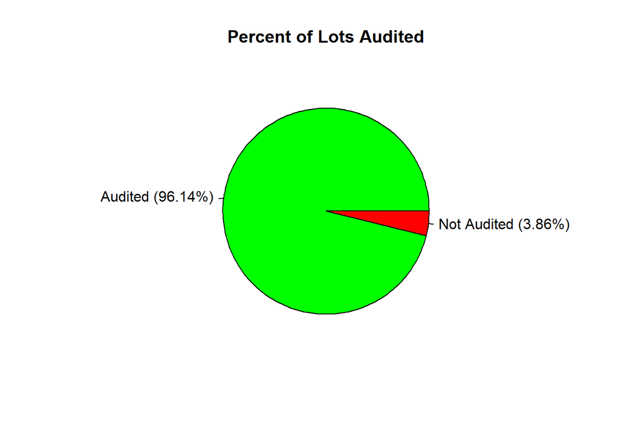

```r
# pie chart of lots audited/remaining to be audited
# audited :
audit_percentage = round(percent_audited_unique_lots, 2)

not_audit_percentage = round((dim(not_audited_lots_df)[1]  / num_unique_lots) * 100, 2)

percentages = c(audit_percentage, not_audit_percentage)

pie(percentages,
    labels = paste0(c("Audited", "Not Audited"), " (", percentages, "%)"),
    col = c("green", "red"),
    main = "Percent of Lots Audited"
)
```

#### **Total Adjustments (pcs) (# & %)**

**THERE ARE 2469 TOTAL ADJUSTMENTS**

```r
# this includes duplicate lots since we're looking for total not unique

# total number of adjustments
total_num_adjustments = length(theoretical_lot_audits$Adjusted..Pcs[which(theoretical_lot_audits$Adjusted..Pcs != "")])

paste("THERE ARE",total_num_adjustments, "TOTAL ADJUSTMENTS")
```

```
## [1] "THERE ARE 2469 TOTAL ADJUSTMENTS"
```

**96.14 PERCENT OF LOTS HAVE HAD AN ADJUSTMENT MADE**

```r
# where the data stops
last_data_index = which(theoretical_lot_audits$Adjusted..Pcs == "" & theoretical_lot_audits$Lot. == "")[1] - 1


# because of the way that I cleaned my data, percentage adjusted is the same as percentage of lots audited

# percentage of adjustments made
paste(round((total_num_adjustments / dim(theoretical_lot_audits[1:last_data_index, ])[1]) * 100, 2), "PERCENT OF LOTS HAVE HAD AN ADJUSTMENT MADE")
```

```
## [1] "96.14 PERCENT OF LOTS HAVE HAD AN ADJUSTMENT MADE"
```

### **OTHER INSIGHTS**

```r
library(ggplot2)
```

**REMOVING DUPLICATES FOR THE UPCOMING OBSERVATIONS BECAUSE THEY MESS WITH SUMS OF COLUMNS**

```r
theoretical_lot_audits =  theoretical_lot_audits[!duplicated(theoretical_lot_audits[, 3]), ]
```

**THESE 10 STYLES HAD THEIR ENTIRE INVENTORY(INITIAL PCS) USED/MISSING**

```
##     style_id percent_leftover initial_amount
## 5     Style5                0              1
## 59   Style66                0              3
## 66   Style75                0              2
## 108 Style127                0              1
## 146 Style173                0              3
## 161 Style190                0              4
## 189 Style218                0              1
## 215 Style245                0              2
## 221 Style251                0              3
## 224 Style254                0              1
```

**THESE 10 STYLES HAD THE MOST INVENTORY(INITIAL PCS) USED/MISSING**

```
##     style_id amount_used_or_missing
## 68   Style78                   29.0
## 81   Style92                   21.0
## 111 Style132                   18.3
## 70   Style80                   17.3
## 35   Style36                   16.0
## 162 Style191                   15.5
## 71   Style82                   12.0
## 171 Style200                   11.5
## 1     Style1                   10.0
## 25   Style25                   10.0
```

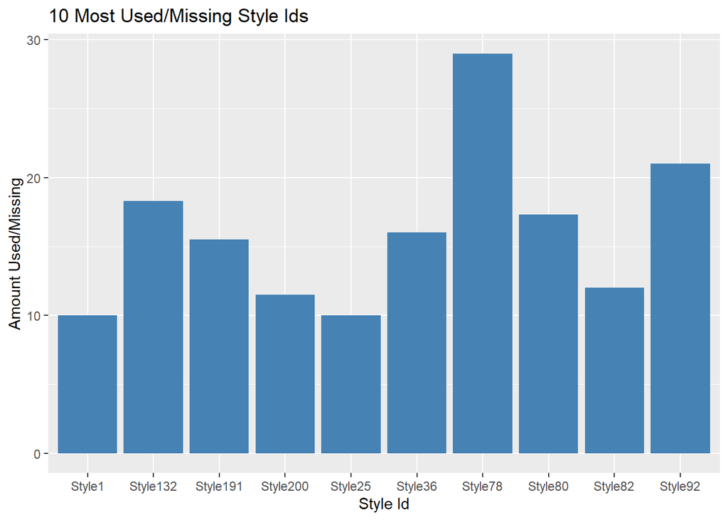

```r
ggplot(top_10_used_styles, aes(x = style_id, y = amount_used_or_missing)) +
  geom_col(fill = "steelblue") +
  labs(title = "10 Most Used/Missing Style Ids", x = "Style Id", y = "Amount Used/Missing")
```

**LOTS RECEIVED PER YEAR** (FOR RECIEVE DATES THAT INCLUDED DATES NOT NUMBER CODES)

```
##   year lots_received
## 1 2022          1150
## 2 2020           234
## 3 2021           871
## 4 2019            21
## 5 2017             9
## 6 2018            11
## 7 2016             1
```

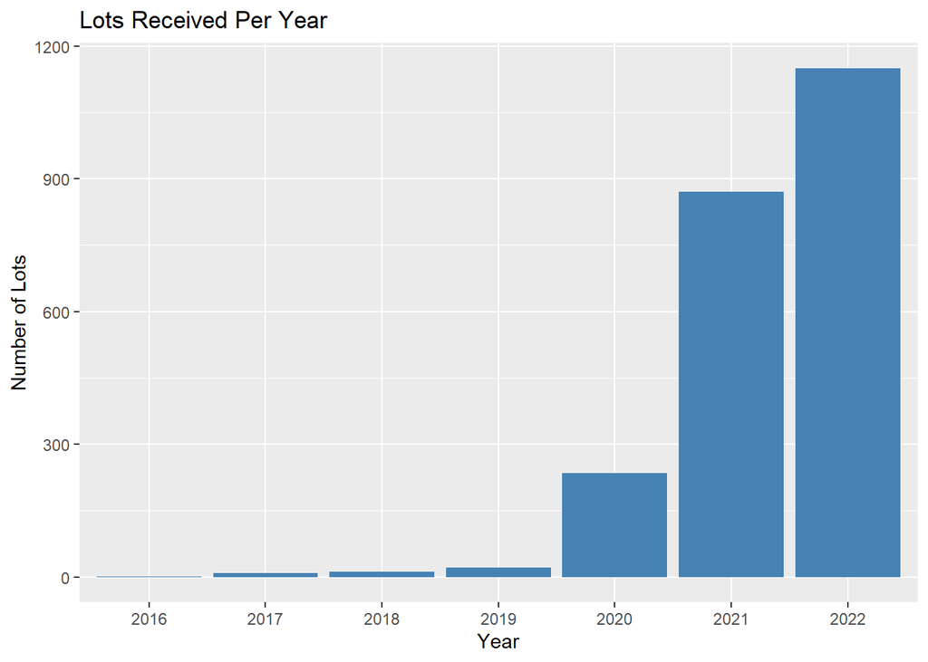

```r
ggplot(lots_per_year_df, aes(x = year, y = lots_received)) +
  geom_col(fill = "steelblue") +
  labs(title = "Lots Received Per Year", x = "Year", y = "Number of Lots")
```